# Building an LDA model to model the topics in the speeches

Aboli Khairnar

Sept, 2020

```r
setwd("/My_Personal_PC/FALL_2020_COURSE_MATERIAL/NLP/Lecture 6/")
```

```r
speeches <- read.csv("../Lecture 3/UN_speeches.csv")
#G8 Nations: United States, England, France, Italy, Germany, Japan, Canada, and Russia.
unique(speeches$country)
```

```
## [1] "CAN" "FRA" "GBR" "ITA" "JPN" "USA" "RUS" "DEU"
```

### Building LDA model to model the topics in the speeches

Data Preprocessing:

```r
countries <- c('united states', 'england', 'france', 'italy', 'germany', 'japan', 'canada', 'russia')
speeches_preprocessed <- pre_process_corpus_adam(speeches, "text", extra_stopwords = countries, root_gen = 'lemmatize')
```

```r
save.image(file = "lab5_workspace.RData")
write.csv(speeches_preprocessed, file = "lab5_preprocessed_data.csv")
```

Building DTM and converting it to a sparse corpus:

```r
it <- itoken(speeches_preprocessed, tokenizer = word_tokenizer)
vocab_full <- create_vocabulary(it, ngram = c(1, 3))
```

```r
lbound <- 2
ubound <- 45

vocab <- vocab_full[vocab_full$doc_count > lbound & vocab_full$doc_count < ubound,]

vectorizer <- vocab_vectorizer(vocab)
dtm <- create_dtm(it, vectorizer)
dim(dtm)

sparse_corpus <- Matrix(dtm, sparse = T)
```

### 1.

Define systematic approach for optimizing K, the number of topics. You can use functions designed for this task or your own methods. Explain how your approach works and why it is effective. Optimizing K (number of topics)

```r
# converting matrix into document-level list of vocab counts
docs <- apply(dtm, 1, function(x){
  tmp <- as.data.frame(x)
  tmp$vocab <- 1:nrow(tmp)
  tmp <- tmp[tmp[,1] >0,]
  tmp <- as.matrix.data.frame(t(tmp[, c(2,1)]))
  return(tmp)
})

# running ksearch function and analyze results
ksearch <- searchK(documents = docs, vocab = colnames(dtm), K = c(3:21))
```

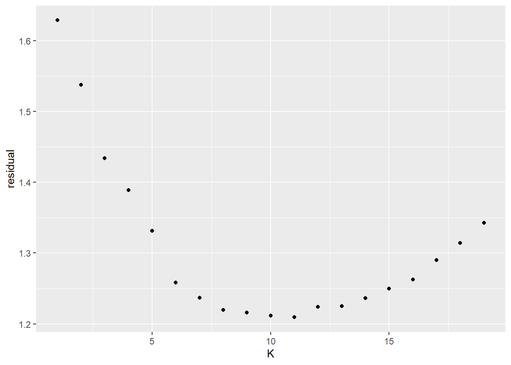

```r
df <- data.frame(K = c(1:19), residual = unlist(ksearch$results$residual))
ggplot(data = df, aes(y = residual, x = K)) + geom_point()
```

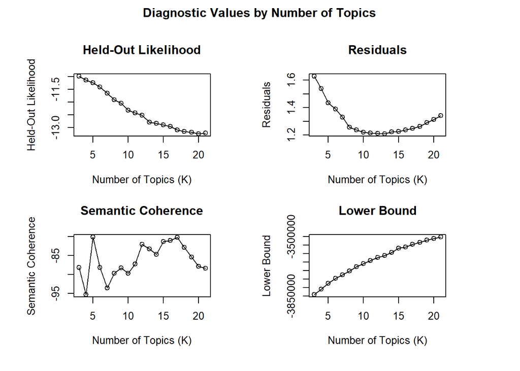

```r
plot(ksearch)
```

With ksearch we can evaluate our model based on metrics like the residuals, the semantic coherence of the topics, the likelihood for held-out datasets. Above plots briefly summarizes how our models are performing at different numbers of topics (K). However these measures are not the best. They are still inferior to human validation of the topic models by carefully inspecting not only the top words associated with each document.

### 2.

Analyze how the G8 countries align on topics and how that alignment has changed over time.

```r
topic_model2 <- stm(sparse_corpus, init.type = 'LDA', seed = 12345,
                   K = 11, control = list(alpha = 64))

topic_prevalence <- as.data.frame(topic_model2$theta)
mean(apply(topic_prevalence, 1, max))
topic_content <- as.data.frame(t(exp(topic_model2$beta$logbeta[[1]])))
topic_names <- apply(topic_content, 2, function(x) {paste(topic_model2$vocab[order(x,
                                      decreasing = T)[1:6]], collapse = " ")})
topic_names
```

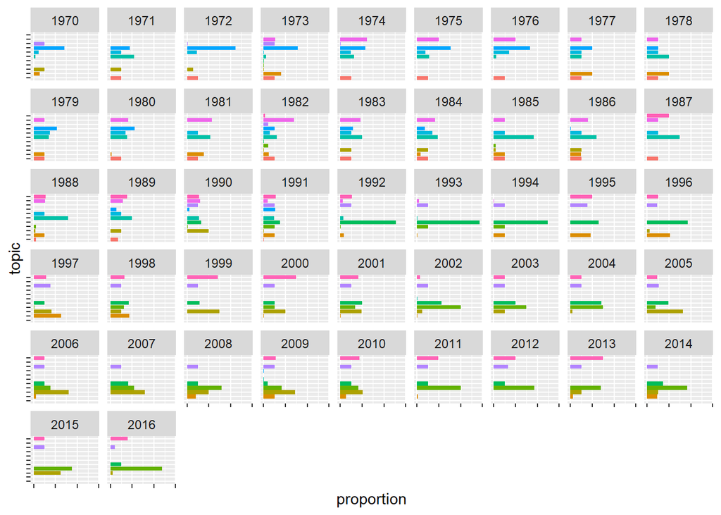

```r
df <- topic_prevalence
colnames(df) <- topic_names
df$year <- as.character(speeches$year)
df <- melt(df, id.vars = 'year', value.name = 'proportion', variable.name = 'topic')

ggplot(df, aes(x = topic, y = proportion, fill = topic)) + geom_bar(stat = 'identity') +
  theme(axis.text.x = element_blank(), axis.text.y = element_blank(), legend.position = "none") +
  coord_flip() + facet_wrap(~ year, ncol = 9)
```

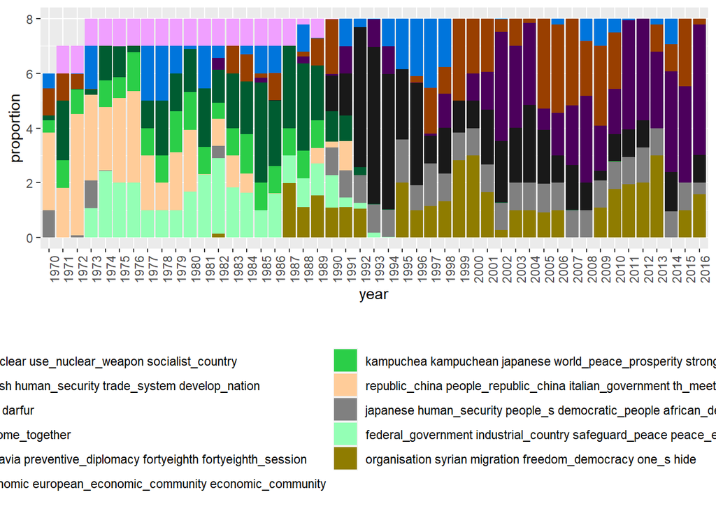

```r
df <- topic_prevalence
colnames(df) <- topic_names
df$year <- as.character(speeches$year)
df <- melt(df, id.vars = 'year', value.name = 'proportion', variable.name = 'topic')

library(pals)
ggplot(df, aes(x = year, y = proportion, fill = topic)) + geom_bar(stat = 'identity') +
  scale_fill_manual(values = paste0(alphabet(20), "FF"), name = "topic") +
  theme(axis.text.x = element_text(angle = 90, hjust = 1), legend.position="bottom") +
  guides(fill = guide_legend(title.position = 'top', ncol = 2))
```